```python
from IPython.display import display_html
display_html("""<button onclick="$('.input, .prompt, .output_stderr, .output_error').toggle();">Toggle Code</button>""", raw=True)
```

# Song Lyrics Data Story

## A deeper look of patterns and characteristics of different types of song lyrics

[figure not shown]

```python
from IPython.display import Image
Image(filename='music3.jpg', width = 700)
```

We all love music and singers, and we may have our favorite playlist that we listen to every day. With the continuous development of technology, we have the opportunity to explore different types of music more and easier. Some of us like Pop music, some like country music, and some enjoy EDM more. Music is everywhere and has become an indispensable part of our life. People love different songs due to different reasons. We can fall in love with a song because of its melody, or sometimes we feel like the lyrics resonate with us so well. It's very interesting to study people's music preferences and the reason behind. Let's take a look at the secret of songs -- the lyrics! And find out the patterns of different types of song lyrics!

## What type of songs do we have?

First, we will take a look at some basic information so that we can get a better understanding of the songs we have. In this part, **the song distribution among music genre**, **artist** and **year of release** will be analyzed.

```python
# load packages

import pandas as pd
import numpy as np
import matplotlib.pyplot as plt
%matplotlib inline
import seaborn as sns
```

```python
# import processed data
data = pd.read_csv('processed_lyrics.csv',index_col = 0)
```

```python
#Create feature 'lyrics length' for each song
data['lyrics_length'] = data['lyrics'].apply(lambda x: len(x) - x.count(' '))
```

### What does the song length distribution look like?

```python
print("Mean of lyrics length:", np.mean(data.lyrics_length))
print("Median of lyrics length:", np.median(data.lyrics_length))
print("Max of lyrics length:", np.max(data.lyrics_length))
print("Min of lyrics length:", np.min(data.lyrics_length))
print('Song with highest lyrics length:', data[data['lyrics_length'] == 30374]['song'][68962])
print('Song with lowest lyrics length:', data[data['lyrics_length'] == 144]['song'][84213])
```

```
Mean of lyrics length: 955.2810491312925
Median of lyrics length: 813.0
Max of lyrics length: 30374
Min of lyrics length: 144
Song with highest lyrics length: yes-sir-i-will
Song with lowest lyrics length: boy-oh-boy-thugli-remix
```

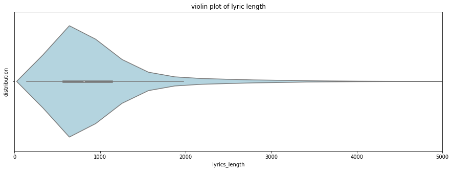

```python
plt.figure(figsize=(15,5))
sns.violinplot(x=data["lyrics_length"], color='lightblue')
plt.title('violin plot of lyric length')
plt.ylabel('distribution')
plt.xlim(0, 5000)
plt.savefig('lyrics length.png')
plt.show()
```

### What are the most popular genre?

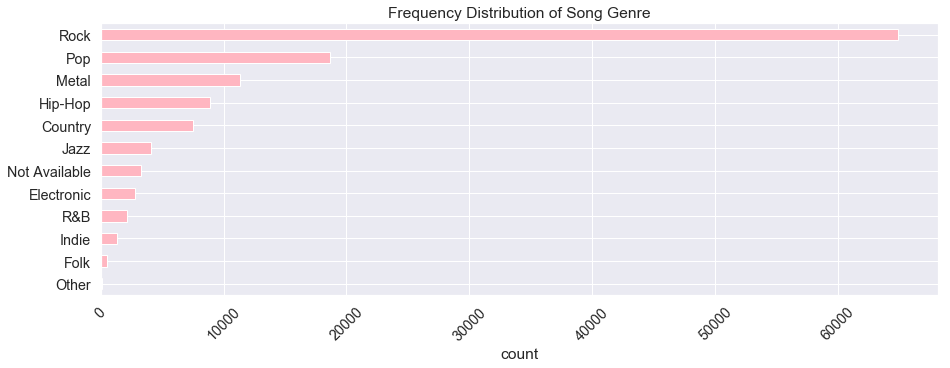

```python
sns.set_style("whitegrid")
sns.set(font_scale=1.3)
plt.figure(figsize=(15,5))

plt.title('Frequency Distribution of Song Genre')
plt.xlabel('count')
plt.xticks(rotation=45)
top_genres = data['genre'].value_counts().sort_values().plot.barh(color='lightpink')
plt.savefig('song genre freq.png')
plt.show()
```

### Which artist has the most songs?

Below shows the top 10 artist ranked by their number of songs released throughout the entire period of time. The top 10 artists all have over 500 songs released.

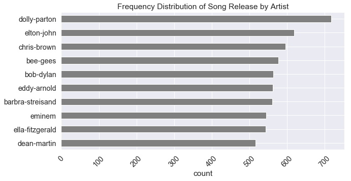

```python
# plot top 10 artist by their number of songs released

plt.figure(figsize=(10,5))
plt.xlabel('count')
plt.xticks(rotation=45)
plt.title("Frequency Distribution of Song Release by Artist")
top_release_year = data['artist'].value_counts()[:10].sort_values().plot.barh(color='grey')
plt.savefig('artist freq.png')
plt.show()
```

### When are songs most frequently released?

Apparently, 2006 and 2007 dominate the the song production among the past decade.

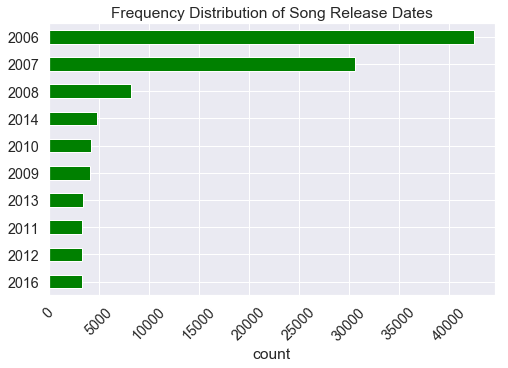

```python
# plot top 10 year that have the most songs released

plt.figure(figsize=(8,5))
plt.xlabel('count')
plt.xticks(rotation=45)
plt.title("Frequency Distribution of Song Release Dates")
top_release_year = data[data['year']>1000]['year'].value_counts()[:10].sort_values().plot.barh(color='green')
plt.savefig('song year freq.png')
plt.show()
```

## How does song lyrics look like?

In order to get a better understanding of song lyrics and find out the patterns and characteristics in it, let's do some more analysis on the **length of the lyrics**, how it changes along **time** and across **genres**. Also, it would be interesting to know if **punctuations** in lyrics matters.

### Does different genre has significanly different lyrics length?

```python
# take a look at songs with lyrics length greater than or equal to 3000

long_lyrics = data[data.lyrics_length >= 3000].groupby('genre').size()
long_lyrics.reset_index(name='count')
```

|  | genre | count |
| --- | --- | --- |
| 0 | Country | 4 |
| 1 | Electronic | 13 |
| 2 | Folk | 5 |
| 3 | Hip-Hop | 1682 |
| 4 | Indie | 1 |
| 5 | Jazz | 6 |
| 6 | Metal | 52 |
| 7 | Not Available | 10 |
| 8 | Other | 1 |
| 9 | Pop | 98 |
| 10 | R&B | 5 |
| 11 | Rock | 135 |

```python
# take a look at songs with lyrics length less than or equal to 300

short_lyrics  = data[data.lyrics_length <= 300].groupby('genre').size()
short_lyrics.reset_index(name='count')
```

|  | genre | count |
| --- | --- | --- |
| 0 | Country | 122 |
| 1 | Electronic | 206 |
| 2 | Folk | 9 |
| 3 | Hip-Hop | 77 |
| 4 | Indie | 48 |
| 5 | Jazz | 220 |
| 6 | Metal | 478 |
| 7 | Not Available | 79 |
| 8 | Other | 3 |
| 9 | Pop | 334 |
| 10 | R&B | 44 |
| 11 | Rock | 1952 |

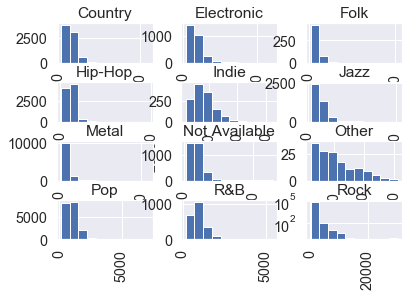

```python
# lyrics length distribution across different genre

data.lyrics_length.hist(by=data['genre'])
plt.gca().set_yscale('log')
plt.savefig('lyrics len vs genre.png')
```

```python
# Calculate how many percentage of songs in each genre has shorter lyrics

short_lyrics = short_lyrics.reset_index(name='count')
total = data['genre'].value_counts()
total = total.reset_index().rename(columns = {'index':'genre','genre':'total'})
df_lyrics = pd.merge(short_lyrics, total, on ='genre')
```

The below result shows that Electronic music has the most short lyrics songs while Hip-Pop music has the least, which matches the previous observation.

```python
df_lyrics['short%'] = (df_lyrics['count']/df_lyrics['total'])*100
df_lyrics
```

|  | genre | count | total | short% |
| --- | --- | --- | --- | --- |
| 0 | Country | 122 | 7534 | 1.619326 |
| 1 | Electronic | 206 | 2812 | 7.325747 |
| 2 | Folk | 9 | 514 | 1.750973 |
| 3 | Hip-Hop | 77 | 8905 | 0.864683 |
| 4 | Indie | 48 | 1318 | 3.641882 |
| 5 | Jazz | 220 | 4122 | 5.337215 |
| 6 | Metal | 478 | 11311 | 4.225975 |
| 7 | Not Available | 79 | 3325 | 2.375940 |
| 8 | Other | 3 | 147 | 2.040816 |
| 9 | Pop | 334 | 18697 | 1.786383 |
| 10 | R&B | 44 | 2174 | 2.023919 |
| 11 | Rock | 1952 | 64845 | 3.010255 |

### What are the top 10 songs with longer lyrics?

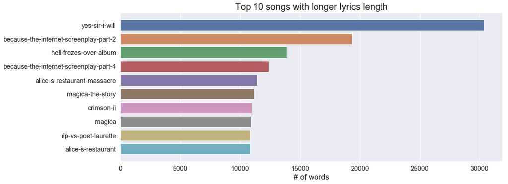

```python
# plot top 10 songs with more lyrics

more_lyrics = data.sort_values('lyrics_length', ascending=False)[:10]

fig, ax = plt.subplots(figsize=(15,6))
ax = sns.barplot(x="lyrics_length", y="song", data=more_lyrics)
plt.ylabel("")
plt.xlabel('# of words', fontsize=17)
plt.title('Top 10 songs with longer lyrics length', fontsize=20)
plt.savefig('top 10 songs with long lyrics.png')
plt.plot();
```

### What are the top 10 songs with shorter lyrics?

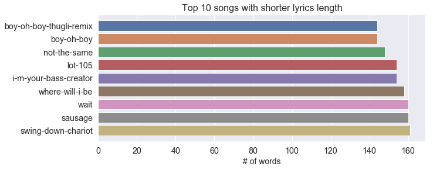

```python
# plot top 10 songs with less lyrics

less_lyrics = data.sort_values('lyrics_length')[:10]

fig, ax = plt.subplots(figsize=(10,4))
ax = sns.barplot(x="lyrics_length", y="song", data=less_lyrics)
plt.ylabel("")
plt.xlabel('# of words', fontsize=14)
plt.title('Top 10 songs with shorter lyrics length', fontsize=16)
plt.savefig('top 10 songs with short lyrics.png')
plt.plot();
```

### How is lyrics length changes along time?

From the graph below, we can see the average lyrics length shows an upwards trend over the last ten years(2007-2016) with the lowest in 2007 and highest in 2011.

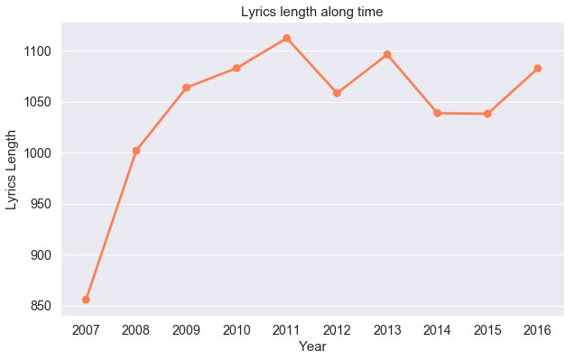

```python
# plot change of average lyrics length along time

fig, ax = plt.subplots(figsize=(10,6))
lyrics_len_by_year = data[['year','lyrics_length']].groupby(['year']).mean()[-10:]
lyrics_len_by_year.reset_index(inplace=True)

ax = sns.pointplot(x='year', y='lyrics_length', data= lyrics_len_by_year, color='coral')
plt.xlabel('Year', fontsize=15)
plt.ylabel('Lyrics Length', fontsize=15)
plt.title('Lyrics length along time', fontsize=15)
plt.savefig('lyrics length along time.png')
plt.plot();
```

### Does percentage of punctuation in lyrics matter?

The violin plot shows that most songs have around 0-5% punctuation in lyrics.

```python
# create feature for % lyrics that is punctuation

import string

def punct_count(lyrics):
    count = sum([1 for char in lyrics if char in string.punctuation])
    return round(count/(len(lyrics) - lyrics.count(' ')),3)*100

data['punct_perc'] = data['lyrics'].apply(lambda x: punct_count(x))
```

```python
print("Mean % of punctuation in song:", np.mean(data.punct_perc))
print("Median % of punctuation in song:", np.median(data.punct_perc))
print("Max % of punctuation in song:", np.max(data.punct_perc))
print("Min % of punctuation in song:", np.min(data.punct_perc))
```

```
Mean % of punctuation in song: 3.463473716031336
Median % of punctuation in song: 3.1
Max % of punctuation in song: 64.5
Min % of punctuation in song: 0.0
```

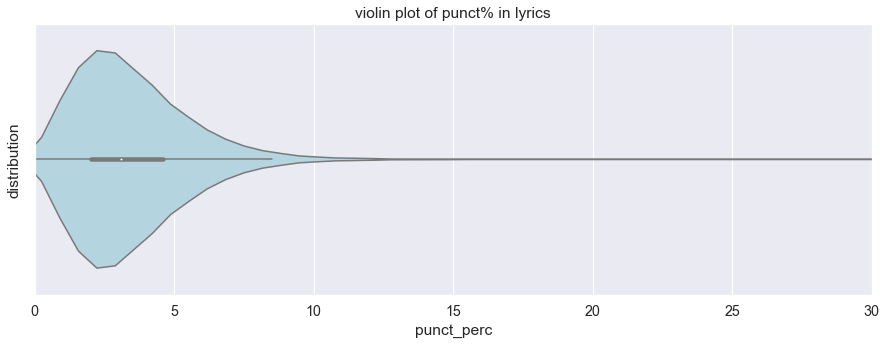

```python
# plot the % of punctuation in all song lyrics

plt.figure(figsize=(15,5))
sns.violinplot(x=data["punct_perc"], color='lightblue')
plt.title('violin plot of punct% in lyrics')
plt.ylabel('distribution')
plt.xlim(0, 30)
plt.savefig('punct% in lyrics.png')
plt.show()
```

### How is punctuation in lyrics differ across genres?

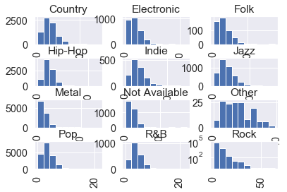

```python
# look at the % of punctuation in lyrics across different genres

data.punct_perc.hist(by=data['genre'])
plt.gca().set_yscale("log")
plt.savefig('punct% vs genre.png')
```

```python
data[data.punct_perc > 10].groupby('genre').size()
```

```
genre
Country           21
Electronic        47
Folk               3
Hip-Hop          136
Indie              6
Jazz              48
Metal             58
Not Available     67
Pop              145
R&B               37
Rock             645
dtype: int64
```

```python
data[data.punct_perc < 1].groupby('genre').size()
```

```
genre
Country           579
Electronic        294
Folk               61
Hip-Hop           111
Indie             101
Jazz              275
Metal            1714
Not Available     181
Other               7
Pop               994
R&B                68
Rock             4402
dtype: int64
```

The result doesn't indicate a strong relationship between punctuation in lyrics and type of music. Therefore, we do not need to consider this feature in future analysis.

## Word Count

After getting some basic information of songs and lyrics, we can take a closer look at the actual text in lyrics. Most importantly, we want to understand if certain words are commonly used in certain type of songs, and are there special sentiments or topics tied to any genre.

### First, let's take a look at the song with longest lyrics and see the frequency of words in the song

From previous analysis, we found that song **'yes-sir-i-will'** has the longest lyrics. Let's check the most common words in this song!

```python
subset = data[data['song'] == 'yes-sir-i-will']
```

```python
from collections import Counter

word_freq = Counter(word for words in subset['stemmedwords'].str.split() for word in words)
print('Top 10 most common words in the song are:', word_freq.most_common(10))
```

```
Top 10 most common words in the song are: [('people', 36), ('world', 24), ('passive', 18), ('war', 18), ('care', 17), ('death', 15), ('suffer', 15), ('power', 13), ('accept', 13), ('thatcher', 13)]
```

### Plot the top 20 words in the song with highest word counts

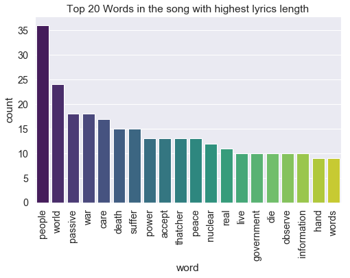

```python
top_words = 20
common_words = pd.DataFrame(word_freq.most_common(top_words), columns=['word', 'count'])

plt.figure(figsize=(8,5))
sns.barplot(x='word', y='count', data=common_words, palette="viridis")
plt.title("Top {} Words in the song with highest lyrics length".format(top_words))
plt.xticks(rotation=90)
plt.savefig('top 20 words in song with longest lyrics.png')
plt.show()
```

### Next, look at the word frequency in all songs and plot the top 20 words that appear in songs

```python
# top 20 words appear in songs

word_freq_songs = Counter(word for words in data['stemmedwords'].str.split() for word in words)
print('Top 20 most common words in all songs are:', word_freq_songs.most_common(20))
```

[output not shown]

### Plot top 20 words used most frequently in all songs

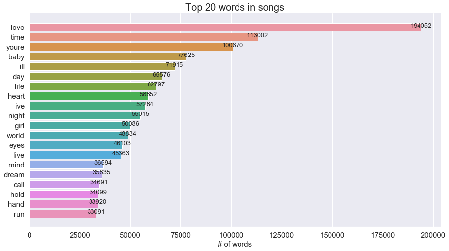

```python
top_20_words = word_freq_songs.most_common(20)
top_20_words = pd.DataFrame(top_20_words, columns = ['word','count'])

fig, ax = plt.subplots(figsize=(15,8))
ax = sns.barplot(x="count", y="word", data=top_20_words)
plt.ylabel("")
plt.xlabel('# of words', fontsize=15)
plt.title('Top 20 words in songs', fontsize=20)
for tick in ax.xaxis.get_major_ticks():
    tick.label.set_fontsize(15)
for tick in ax.yaxis.get_major_ticks():
    tick.label.set_fontsize(15)
for p in ax.patches:
    width = p.get_width()
    ax.text(width + 8  ,
            p.get_y() + p.get_height()/2.,
            "%d" % width,
            ha="center", fontsize=13)
sns.despine()
plt.savefig('top 20 words in songs.png')
plt.plot();
```

## Summary

By utilizing topic modeling techinique, we grouped the words in lyrics into 8 topis and below shows 10 keywords under each topics.

```python
#Apply TFIDF Vecterizer

from sklearn.feature_extraction.text import TfidfVectorizer

tfidf_vect = TfidfVectorizer(stop_words='english', min_df=10, max_df=0.9)
X_tfidf = tfidf_vect.fit_transform(data['stemmedwords']) # fit vectors of unique word counts in stemmed words
#print('TFIDF matrix dimensions:',X_tfidf.shape)
#print(tfidf_vect.get_feature_names())
```

```python
# Latent Dirichlet Allocation(LDA)

from sklearn.decomposition import LatentDirichletAllocation as LDA

k_topics = 8
lda = LDA(n_components=k_topics, max_iter=10, learning_method='online', random_state=1234)
lda.fit(X_tfidf)
```

```
LatentDirichletAllocation(batch_size=128, doc_topic_prior=None,
             evaluate_every=-1, learning_decay=0.7,
             learning_method='online', learning_offset=10.0,
             max_doc_update_iter=100, max_iter=10, mean_change_tol=0.001,
             n_components=8, n_jobs=None, n_topics=None, perp_tol=0.1,
             random_state=1234, topic_word_prior=None,
             total_samples=1000000.0, verbose=0)
```

```python
tfidf_features = tfidf_vect.get_feature_names()
top_n_words = 10
word_dict = dict()

for i in range(0,k_topics):
    topic = pd.DataFrame(data={'word':tfidf_features, 'weight':lda.components_[i]})
    sorted_topic = topic.sort_values('weight', ascending=False).head(top_n_words)
    word_dict[i+1] = list(sorted_topic['word'])

pd.DataFrame(word_dict)
```

|  | 1 | 2 | 3 | 4 | 5 | 6 | 7 | 8 |
| --- | --- | --- | --- | --- | --- | --- | --- | --- |
| 0 | ba | love | girl | bye | adore | throne | horse | love |
| 1 | grind | baby | baby | hallelujah | crown | tragedy | cowboy | time |
| 2 | eh | youre | ya | block | holy | severed | gimme | life |
| 3 | boom | time | shit | ghetto | thy | infected | johnny | youre |
| 4 | satellite | ill | em | nah | master | sow | evry | day |
| 5 | robot | heart | boy | mo | universe | worthless | wow | world |
| 6 | automatic | ive | rock | tha | garden | reap | everytime | eyes |
| 7 | jenny | day | money | jones | salvation | revelation | cha | ive |
| 8 | program | girl | yo | jingle | birth | starlight | teenage | ill |
| 9 | ooo | life | bitch | hoo | christ | disgrace | righteous | live |

Based the above LDA result, here are the interpretations of each topic:

Topic 1: technology/universe/outer space  
Topic 2: hapiness/love  
Topic 3: dark(sensitive words)  
Topic 4: obstacles/challenges  
Topic 5: life purpose/goal  
Topic 6: sorrow  
Topic 7: lifestyle/countryside  
Topic 8: travel/life

We also notice that some of the keywords are overlapped with others under different topics, which indicates that their topics are similar and we may try to reduce the number of topics in further analysis to improve accuracy of result.

### Wordcloud

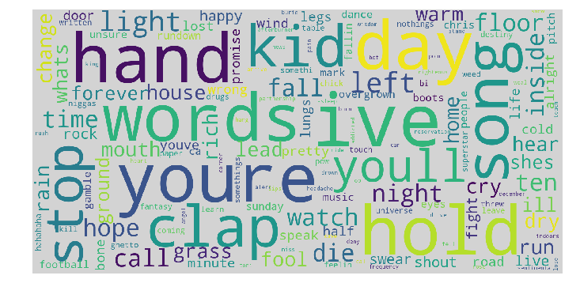

```python
from wordcloud import WordCloud, STOPWORDS
stopwords = set(STOPWORDS)

def show_wordcloud(data):
    wordcloud = WordCloud(
        background_color='lightgrey',
        stopwords=stopwords,
        max_words=150,
        max_font_size=55,
        scale=4,
    ).generate(str(data))

    fig = plt.figure(1, figsize=(12, 12))
    plt.axis('off')
    plt.imshow(wordcloud)
    plt.show()

show_wordcloud(data['stemmedwords'])
```

### Show wordclouds for top 5 genre

### - Rock

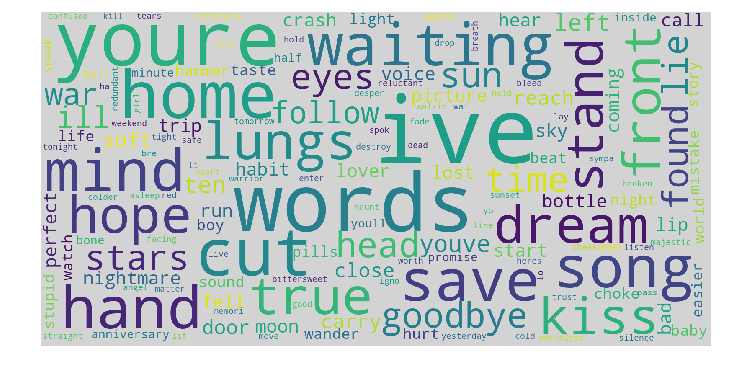

```python
Rock_cloud = data[data['genre']=='Rock']['stemmedwords']
show_wordcloud(Rock_cloud)
```

### - Pop

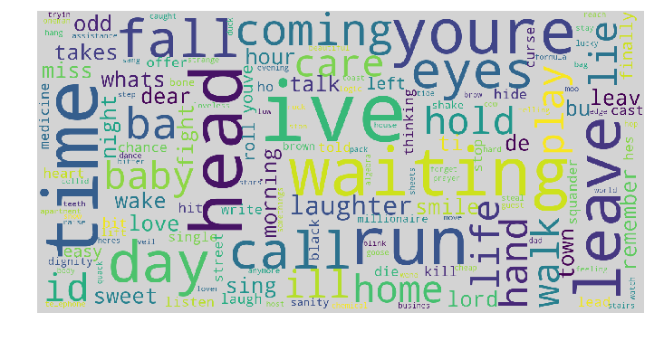

```python
Pop_cloud = data[data['genre']=='Pop']['stemmedwords']
show_wordcloud(Pop_cloud)
```

### - Metal

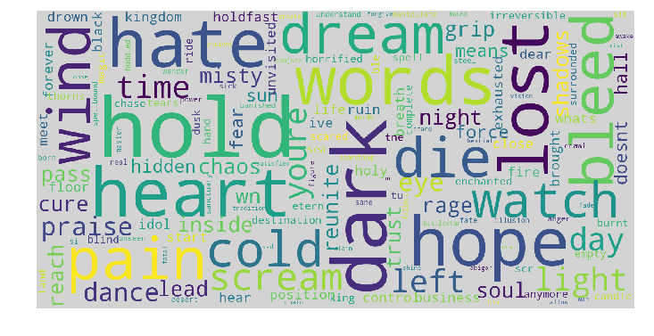

```python
Metal_cloud = data[data['genre']=='Metal']['stemmedwords']
show_wordcloud(Metal_cloud)
```

### - Hip-Hop

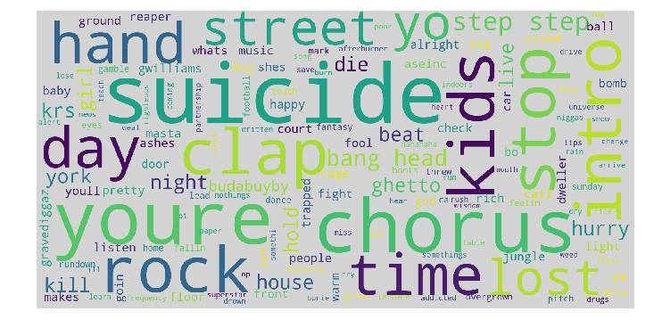

```python
hiphop_cloud = data[data['genre']=='Hip-Hop']['stemmedwords']
show_wordcloud(hiphop_cloud)
```

### - Country

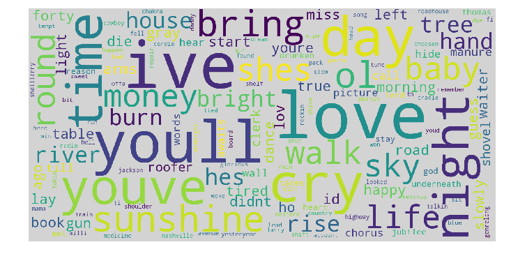

```python
Country_cloud = data[data['genre']=='Country']['stemmedwords']
show_wordcloud(Country_cloud)
```

After looking at the wordcloud for each genre, we can assign topics to each genre based on the keywords and sentiments:

Topic 4: obstacles/challenges --> Pop  
Topic 2: hapiness/love and Topic 7: lifestyle --> Country  
Topic 5: life purpose/goal --> Rock  
Topic 3: dark --> Hip-Pop  
Topic 6: sorrow --> Metal

It is very interesting that although different genres share a lot of common words such as love, youre, ive, time, bab, etc., they do have significanly emotions, and they differ in lyrics length too.